# Study 1: Hormones and Behavior

Shuying Yu

7/22/2022

*Modified on:* February 8th, 2022

# Introduction

Study 1 aims to investigate the relationship between sex hormones and spatial navigation behavior in midlife women and men.

# Research Question

Do sex hormones (estradiol, progesterone, FSH) covary with dependent variables in each spatial navigation task (LOOP, MAZE, DSP) for midlife women and men?

**Prediction:** The decline in ovarian estradiol production in midlife women will be associated with a shift in performance characteristics across spatial navigation paradigms, including more position errors in the LOOP task, fewer correct targets in the MAZE task, and an increased reliance on response-based strategies in the DSP task. For men, I hypothesize that lower testosterone concentrations will also be associated with more position errors in the LOOP task, fewer correct targets in the MAZE task, and an increased reliance on response-based strategies in the DSP task.

Does the ratio of E/FSH among midlife women covary with position error in LOOP, accuracy in MAZE, or navigation strategy in DSP?

**Prediction:** Women with higher ratio of FSH to E (estradiol) will have more position errors in LOOP, less accuracy in MAZE, and more likely to use response-based strategies in DSP compared to women with higher E to FSH.

Another (future) aim is to characterize the change in spatial navigation behavior for men and women from young to midlife. Using data collection from young adults (SNAG, OHS, HAS),I will plot how changes in behavior change with age for mainly women and men.

# Methods

## Participants

Midlife Adults

Sample size and age for women and men grouped by overall completion of spatial navigation behavior.

| Sex | Overall n | Overall Mean Age | Overall SD Age | LOOP n | LOOP Mean Age | LOOP SD Age | MAZE n | MAZE Mean Age | MAZE SD Age | DSP n | DSP Mean Age | DSP SD Age |
| --- | --- | --- | --- | --- | --- | --- | --- | --- | --- | --- | --- | --- |
| Female | 81 | 50.66667 | 3.691206 | 32 | 50.12500 | 3.598835 | 64 | 50.40625 | 3.490207 | 47 | 50.36170 | 3.516579 |
| Male | 36 | 50.83333 | 4.299502 | 22 | 51.22727 | 4.439346 | 23 | 49.91304 | 4.316070 | 29 | 50.37931 | 4.287972 |

**WOMEN**

Some women only had a few hormones available for analysis:

- 335: only have E, did LOOP
- 336: only have E, did MAZE
- 338: only have E, did LOOP and MAZE
- 344: only have E, did LOOP and MAZE
- 349: only have E, did LOOP
- 367: only have E & T, did LOOP and DSP
- 371: only have E & T, did only LOOP

Thus for women, sample sizes in the following correlation analyses are

- Estradiol: *n* = 32 for LOOP, *n* = 64 for MAZE, and *n* = 47 for DSP.
- Progesterone: *n* = 26 for LOOP, *n* = 61 for MAZE, and *n* = 46 for DSP.
- FSH: *n* = 26 for LOOP, *n* = 61 for MAZE, and *n* = 46 for DSP.

**MEN**

- 365: only have SHBG, did LOOP and DSP

Thus for men, sample sizes in the following correlation analyses are *n* = 21 for LOOP, *n* = 23 for MAZE, and *n* = 28 for DSP.

## Task Paradigms

Same as those reported in *Yu et al. (2021)*. Hormones are testosterone for men; and estradiol, progesterone, FSH for women. Hormones are taken during time of spatial navigation task.

Difference between DSP path efficiency using grid distance and grid distance weighted are not statistically different, so use the weighted version.

For now, MAZE path efficiency scores have been updated but are not yet finalized (January 17th, 2022).

# Results

## Men: Hormone and Behavior Correlations

Spearman rank correlations were used for LOOP degrees at radius 3.0m, MAZE accuracy, DSP solution index. All other correlations for men were Pearson.

### LOOP

Degrees traveled at 3.0m was negatively correlated with testosterone ($\rho$ = -0.484, 95% CI = [-0.776, -0.022], *p* < 0.05). No other significant correlations for position error or angular error.

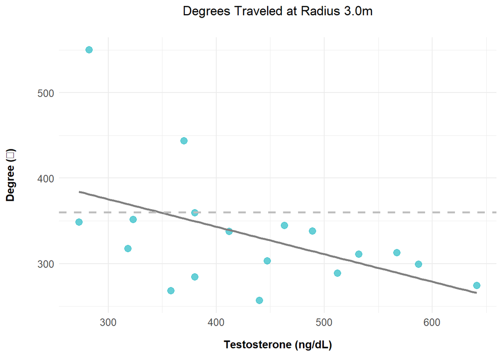

### MAZE

No significant correlations for accuracy, movees, or path efficiency.

### DSP

No significant correlations for wayfinding success, solution index, or path efficiency

## Women: Hormone and Behavior Correlations

Hormones bar plot using spatial hormones

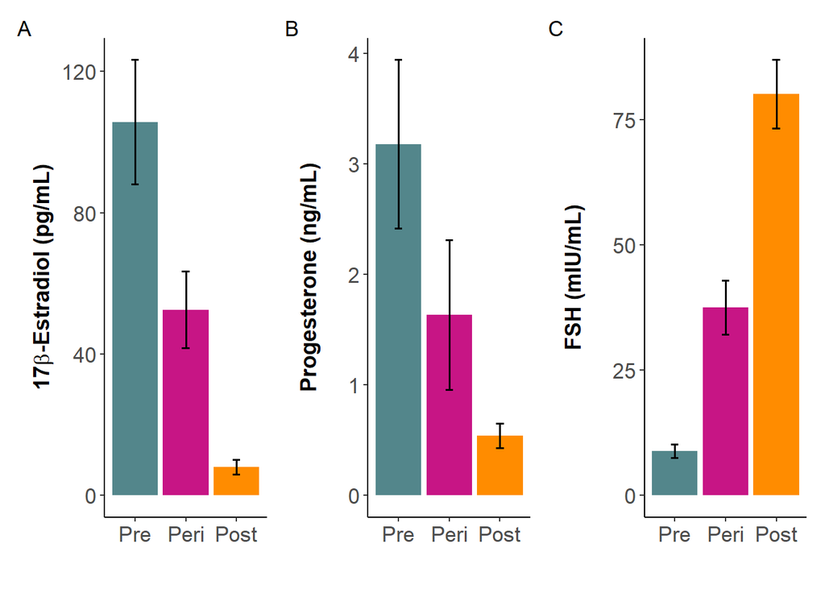

Kruskal-Wallis rank sum test was used for non-normal comparison between reproductive groups for estradiol, progesterone, and FSH dependent variables. If significant, pairwise comparisons were made using Wilcoxon rank sum test with Benjamini, Hochberg, and Yekutieli *p*-adjustments to control the false discovery rate.

Estradiol is statistically significant between all pairs of reproductive groups (at least *p* < 0.01), as well as FSH (at least *p* < 0.001). Progesterone was different between pre-post (*p* < 0.01) and peri-post (*p* < 0.05).

Hormones were skewed despite log transformations, thus Spearman rank correlations were applied for all correlations between behavior and the raw hormone values.

### LOOP

No significant correlations for position error, degrees traveled, or angular error.

### MAZE

No correlations for accuracy, moves, or path efficiency.

### DSP

No correlation for wayfinding success or path efficiency, but significant positive correlation for solution index for estradiol ($\rho$ = 0.421, *p* < 0.01) and negative marginal correlation for FSH ($\rho$ = -0.281, *p* = 0.058).

Kruskal-Wallis test of DSP solution index by reproductive status for women was not significant.

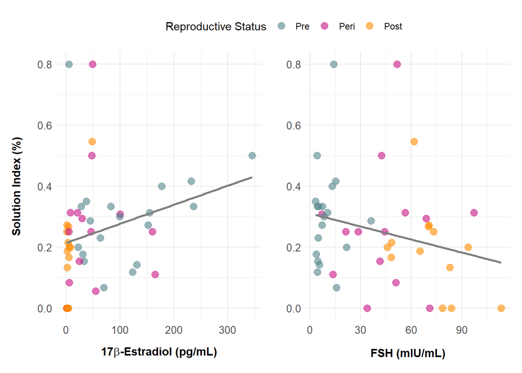

# Summary

- Men were tested separately for the relationship between testosterone and spatial navigation behaviors, while women were tested for the relationships between estradiol, progesterone, FSH and spatial navigation behaviors.
- LOOP degrees traveled at 3.0m was negatively correlation with testosterone for men ($\rho$ = -0.484, 95% CI = [-0.776, -0.022], *p* < 0.05).
- Estradiol, progesterone, and FSH were skewed, so associations with these hormones were using Spearman rank correlations.
- No significant correlations for LOOP or MAZE among women.
- While there were no significant correlations for DSP wayfinding success or path efficiency, there was a positive correlation between estradiol and solution index ($\rho$ = 0.421, 95% CI = [0.153, 0.632], *p* < 0.01, Spearman), and a marginal negative association between FSH and solution index ($\rho$ = -0.281, 95% CI = [-0.529, 0.010], *p* = 0.058, Spearman). There was also no significant correlation with progesterone and solution index ($\rho$ = 0.16, 95% CI = [-0.136, 0.431], *p* = 0.29, Spearman). This was true when using hormone measurements from spatial timepoints.
- Kruskla-Wallis test reveals that DSP solution index by reproductive status was not significant.
- When using estradiol to FSH ratio (or FSH to estradiol ratio) as a single measure for hormone concentration, the relationship with DSP solution index remained significant ($\rho$ = 0.420, 95% CI = [0.148, 0.633], *p* < 0.01, Spearman).